# Алгоритмы и реализация модели DLA

Второй этап группового проекта

Казазаев Даниил Михайлович

1132231427@rudn.ru

Симонова Виктория Игоревна

1132236012@rudn.ru

Малюга Валерия Васильевна

1132236050@rudn.ru

Ларина Наталья Денисовна

1132236025@rudn.ru

Лисенков Егор Романович

1132232881@rudn.ru

2026-04-11

# Введение

## Цель второго этапа

- Детальная разработка **алгоритмов** модели DLA и её модификаций.
- Описание **структур данных** и **методов оптимизации**.
- Формализация алгоритмов расчёта **фрактальной размерности**.
- Подготовка к программной реализации.

# Базовый алгоритм DLA (сеточная модель)

## Инициализация

- Квадратная решётка размером $N \times N$, центр $(x_c, y_c)$.
- Затравочная частица в центре.
- Параметры:
  - $R_{\text{spawn}}$ — радиус старта новых частиц.
  - $R_{\text{kill}}$ — радиус обрыва блуждания.

## Основной цикл

1. **Генерация** частицы на окружности $R_{\text{spawn}}$.
2. **Случайное блуждание** по 4 направлениям.
3. **Проверка прилипания**: если соседний узел занят → частица добавляется в кластер.
4. Если частица вышла за $R_{\text{kill}}$ → уничтожается, запускается новая.
5. Периодическое обновление $R_{\text{spawn}}$ и $R_{\text{kill}}$.

# Иллюстрация процесса DLA

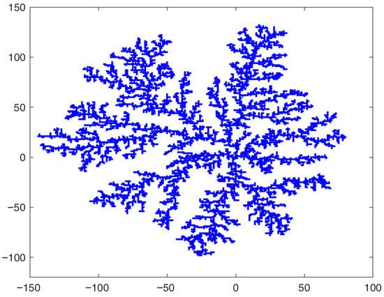

# Адаптация параметров

- $R_{\max}$ — максимальное расстояние от центра до любой частицы кластера.
- **Радиус старта**: $R_{\text{spawn}} = R_{\max} + 2$  
  (минимизация холостого блуждания).
- **Радиус гибели**: $R_{\text{kill}} = \max(3 R_{\max},\, R_{\max}+10)$.
- При добавлении новой частицы $R_{\max}$ пересчитывается за $O(1)$ (сравнение с текущим значением).

# Оптимизация: список граничных узлов

- **Граничный узел** — свободный узел, соседний хотя бы с одним занятым.
- При добавлении частицы:
  - Новый узел удаляется из списка граничных.
  - Его свободные соседи добавляются в список (если отсутствуют).
- Проверка прилипания сводится к проверке принадлежности текущего узла списку граничных.
- **Ускорение**: до 4 раз по сравнению с проверкой всех соседей.

# Алгоритмы расчёта фрактальной размерности

## Метод радиуса гирации

- Вычисляется в процессе роста.
- Центр масс:
  $$\mathbf{R}_{cm} = \frac{1}{N}\sum \mathbf{r}_i$$
- Радиус гирации:
  $$R_g = \sqrt{\frac{1}{N}\sum |\mathbf{r}_i - \mathbf{R}_{cm}|^2}$$
- Зависимость: $\ln N = D \ln R_g + C$.
- Наклон линейной регрессии даёт $D$.

## Метод box‑counting

- Применяется к готовому кластеру.
- Разбиение на ячейки размера $\epsilon$, подсчёт $N(\epsilon)$.
- Строится график $\ln N(\epsilon)$ от $\ln(1/\epsilon)$.
- Наклон прямой — фрактальная размерность.

Таблица 1: Методы расчёта фрактальной размерности для DLA

[output not shown]

# Модификации базовой модели

## Химически ограниченная агрегация (RLA)

- Параметр вероятности прилипания $p \in (0,1]$.
- При обнаружении занятого соседа генерируется случайное число $r \in [0,1)$.
- Прилипание только если $r < p$.
- Позволяет частицам проникать вглубь, увеличивая плотность и $D$.

## Баллистическая агрегация

- Частицы движутся по прямым линиям.
- Прилипают в первой точке контакта с кластером.
- Требует алгоритма трассировки луча (например, Брезенхема).

# Модификации (продолжение)

## Кластер-кластерная агрегация (DLCA)

- Все частицы подвижны и могут образовывать кластеры.
- При столкновении кластеры сливаются.
- Коэффициент диффузии может зависеть от размера кластера:
  $$D_s \sim s^\gamma$$
  где $s$ — масса кластера, $\gamma \approx -0.5$.
- Размерность агрегатов обычно ниже, чем в DLA ($D \approx 1.45$).

Таблица 2: Сравнение фрактальных размерностей для разных моделей

| Модель | $D$ | Плотность |
| --- | --- | --- |
| DLA | $1.71 \pm 0.02$ | Низкая |
| RLA ($p=0.1$) | $\approx 1.85$ | Средняя |
| Баллистическая | $\approx 1.95$ | Высокая |
| DLCA | $\approx 1.45$ | Очень низкая |

# Структуры данных и программная архитектура

- **Решётка**: двумерный массив `grid[1..N, 1..N] of Byte`.
- **Список частиц**: динамический массив координат для анализа.
- **Список граничных узлов**: реализуется через хеш-таблицу или отдельный массив флагов.
- **Модули**:
  - `DLA_Core` — основной алгоритм.
  - `Visualization` — отрисовка кластера.
  - `FractalAnalysis` — расчёт $R_g$ и box‑counting.
  - `Config` — параметры симуляции.

# Псевдокод базового шага

**Алгоритм одного шага блуждания:**

```
while not stuck and (dist < RKill) do
begin
dir := Random(4);
UpdatePosition(x, y, dir);
if IsBoundary(x, y) then
begin
AddToCluster(x, y);
UpdateBoundaryList(x, y);
stuck := true;
end;
end;
```

# Псевдокод: обновление граничного списка

```
procedure UpdateBoundaryList(x, y: Integer);
var
nx, ny: Integer;
dir: array[0..3] of TPair;
begin

RemoveFromBoundary(x, y);

dir := [(-1,0), (1,0), (0,-1), (0,1)];

for i := 0 to 3 do
begin
nx := x + dir[i].x;
ny := y + dir[i].y;
```

## Псевдокод: обновление граничного списка

```
if InBounds(nx, ny) and IsEmpty(nx, ny) then
if not IsInBoundaryList(nx, ny) then
AddToBoundary(nx, ny);
end;
end;
```

# Псевдокод: инкрементальный расчёт $R_g$

```
procedure UpdateRadiusOfGyration(x, y: Integer);
var
new_N: Integer;
old_x_cm, old_y_cm: Double;
begin
N := N + 1;

old_x_cm := x_cm;
old_y_cm := y_cm;

x_cm := x_cm + (x - x_cm) / N;
y_cm := y_cm + (y - y_cm) / N;
```

## Псевдокод: инкрементальный расчёт $R_g$

```
S := S + (x - old_x_cm) * (x - x_cm) +
(y - old_y_cm) * (y - y_cm);

R_g := sqrt(S / N);
end;
```

# Вычислительная сложность

Таблица 3: Сравнение вычислительной сложности с оптимизациями и без них

[output not shown]

# Заключение

- Разработаны детальные алгоритмы модели DLA и её вариантов.
- Предложены эффективные структуры данных и методы оптимизации:
  - список граничных узлов (ускорение до 4 раз),
  - адаптивные радиусы старта и гибели,
  - инкрементальный расчёт радиуса гирации.
- Формализованы процедуры расчёта фрактальной размерности:
  - метод радиуса гирации,
  - метод box‑counting.
- Алгоритмическая база готова к непосредственной программной реализации.